# Framingham Heart Study

- Show All Code
- Hide All Code
- View Source

Author

Affiliation

Frank Harrell

Department of Biostatistics  
Vanderbilt University School of Medicine  
MSCI Biostatistics II

Published

January 26, 2023

```r
require(rms)
options(prType='html')
```

# 1 Problem

# 2 Data Preparation

## 2.1 Data Import

```r
fram <- read.csv('http://hbiostat.org/data/repo/2.20.Framingham.csv')
d <- upData(fram,
            age = ifelse(id == 2642, 103, age),
            labels = .q(sbp = 'Systolic Blood Pressure',
                        bmi = 'Body Mass Index',
                        scl = 'Serum Cholesterol'),
            units  = .q(sbp = mmHg))
```

Input object size: 208704 bytes; 10 variables 4699 observations Modified variable age New object size: 210544 bytes; 10 variables 4699 observations

```r
html(contents(d))
```

| Name | Labels | Units | Class | Storage | NAs |
| --- | --- | --- | --- | --- | --- |
| sex |  |  |  | integer | 0 |
| sbp | Systolic Blood Pressure | mmHg | integer | integer | 0 |
| dbp |  |  |  | integer | 0 |
| scl | Serum Cholesterol |  | integer | integer | 33 |
| chdfate |  |  |  | integer | 0 |
| followup |  |  |  | integer | 0 |
| age |  |  |  | integer | 0 |
| bmi | Body Mass Index |  | numeric | double | 9 |
| month |  |  |  | integer | 0 |
| id |  |  |  | integer | 0 |

## 2.2 Descriptive Statistics

```r
html(describe(d))
```

| n | missing | distinct | Info | Mean | Gmd |
| --- | --- | --- | --- | --- | --- |
| 4699 | 0 | 2 | 0.738 | 1.564 | 0.4919 |

```
 Value          1     2
 Frequency   2049  2650
 Proportion 0.436 0.564
```

sbp: Systolic Blood Pressure mmHg

| n | missing | distinct | Info | Mean | Gmd | .05 | .10 | .25 | .50 | .75 | .90 | .95 |
| --- | --- | --- | --- | --- | --- | --- | --- | --- | --- | --- | --- | --- |
| 4699 | 0 | 116 | 0.999 | 132.8 | 24.36 | 104 | 108 | 116 | 130 | 144 | 162 | 176 |

lowest : 80 84 85 88 90 , highest: 242 254 260 264 270

dbp

| n | missing | distinct | Info | Mean | Gmd | .05 | .10 | .25 | .50 | .75 | .90 | .95 |
| --- | --- | --- | --- | --- | --- | --- | --- | --- | --- | --- | --- | --- |
| 4699 | 0 | 69 | 0.997 | 82.54 | 14.03 | 64 | 68 | 74 | 80 | 90 | 100 | 105 |

lowest : 40 48 50 51 52 , highest: 135 140 142 144 148

scl: Serum Cholesterol

| n | missing | distinct | Info | Mean | Gmd | .05 | .10 | .25 | .50 | .75 | .90 | .95 |
| --- | --- | --- | --- | --- | --- | --- | --- | --- | --- | --- | --- | --- |
| 4666 | 33 | 248 | 1 | 228.3 | 49.08 | 165 | 175 | 197 | 225 | 255 | 286 | 308 |

lowest : 115 117 118 121 124 , highest: 479 492 493 534 568

chdfate

| n | missing | distinct | Info | Sum | Mean | Gmd |
| --- | --- | --- | --- | --- | --- | --- |
| 4699 | 0 | 2 | 0.646 | 1473 | 0.3135 | 0.4305 |

followup

| n | missing | distinct | Info | Mean | Gmd | .05 | .10 | .25 | .50 | .75 | .90 | .95 |
| --- | --- | --- | --- | --- | --- | --- | --- | --- | --- | --- | --- | --- |
| 4699 | 0 | 2805 | 0.986 | 8061 | 3997 | 1449 | 2439 | 5136 | 8908 | 11648 | 11688 | 11688 |

lowest : 18 35 109 147 169 , highest: 11684 11685 11686 11687 11688

age

| n | missing | distinct | Info | Mean | Gmd | .05 | .10 | .25 | .50 | .75 | .90 | .95 |
| --- | --- | --- | --- | --- | --- | --- | --- | --- | --- | --- | --- | --- |
| 4699 | 0 | 39 | 0.999 | 46.05 | 9.796 | 34 | 35 | 39 | 45 | 53 | 58 | 60 |

lowest : 30 31 32 33 34 , highest: 64 65 66 68 103

bmi: Body Mass Index

| n | missing | distinct | Info | Mean | Gmd | .05 | .10 | .25 | .50 | .75 | .90 | .95 |
| --- | --- | --- | --- | --- | --- | --- | --- | --- | --- | --- | --- | --- |
| 4690 | 9 | 248 | 1 | 25.63 | 4.464 | 19.80 | 20.90 | 22.80 | 25.20 | 28.00 | 30.70 | 32.75 |

lowest : 16.2 16.4 16.5 16.7 16.9 , highest: 44.2 48.3 49.5 50.8 57.6

month

| n | missing | distinct | Info | Mean | Gmd | .05 | .10 | .25 | .50 | .75 | .90 | .95 |
| --- | --- | --- | --- | --- | --- | --- | --- | --- | --- | --- | --- | --- |
| 4699 | 0 | 12 | 0.991 | 6.369 | 4.218 | 1 | 2 | 3 | 6 | 10 | 11 | 12 |

lowest : 1 2 3 4 5 , highest: 8 9 10 11 12

```
 Value          1     2     3     4     5     6     7     8     9    10    11    12
 Frequency    456   543   425   401   370   330    29   371   451   508   412   403
 Proportion 0.097 0.116 0.090 0.085 0.079 0.070 0.006 0.079 0.096 0.108 0.088 0.086
```

id

| n | missing | distinct | Info | Mean | Gmd | .05 | .10 | .25 | .50 | .75 | .90 | .95 |
| --- | --- | --- | --- | --- | --- | --- | --- | --- | --- | --- | --- | --- |
| 4699 | 0 | 4699 | 1 | 2350 | 1567 | 235.9 | 470.8 | 1175.5 | 2350.0 | 3524.5 | 4229.2 | 4464.1 |

# 3 Linear Model With Outlier in Data

## 3.1 Fit

- Allow sex to modify the effects of the other three variables
- Predicting untransformed `sbp` resulted in very problematic qq plot
- Taking log(`sbp`) solved $\frac{1}{2}$ the problem

We take logs of BMI and cholesterol in the hope of leading to more linear relationships.

```r
dd <- datadist(d); options(datadist='dd')
f <- ols(log(sbp) ~ sex * (log(bmi) + age + log(scl)), data=d, x=TRUE)
f
```

**Linear Regression Model**

```
 ols(formula = log(sbp) ~ sex * (log(bmi) + age + log(scl)), data = d,
     x = TRUE)
```

Frequencies of Missing Values Due to Each Variable

```
 log(sbp)      sex      bmi      age      scl
        0        0        9        0       33
```

|  | Model Likelihood Ratio Test | Discrimination Indexes |
| --- | --- | --- |
| Obs 4658 | LR χ<sup>2</sup> 1367.68 | *R*<sup>2</sup> 0.254 |
| σ 0.1393 | d.f. 7 | *R*<sup>2</sup><sub>adj</sub> 0.253 |
| d.f. 4650 | Pr(>χ<sup>2</sup>) 0.0000 | *g* 0.091 |

Residuals

```
      Min       1Q   Median       3Q      Max
 -0.44547 -0.09418 -0.01056  0.08131  0.70499
```

|  | β | S.E. | *t* | Pr(>\|*t*\|) |
| --- | --- | --- | --- | --- |
| Intercept | 3.7868 | 0.2404 | 15.75 | <0.0001 |
| sex | -0.2333 | 0.1432 | -1.63 | 0.1035 |
| bmi | 0.2316 | 0.0508 | 4.56 | <0.0001 |
| age | -0.0016 | 0.0008 | -1.92 | 0.0544 |
| scl | 0.0739 | 0.0378 | 1.95 | 0.0507 |
| sex × bmi | 0.0185 | 0.0293 | 0.63 | 0.5267 |
| sex × age | 0.0050 | 0.0005 | 9.64 | <0.0001 |
| sex × scl | -0.0089 | 0.0231 | -0.39 | 0.7000 |

## 3.2 Diagnostics

On the first plot, distinguish the one molested point from the others by making it red.

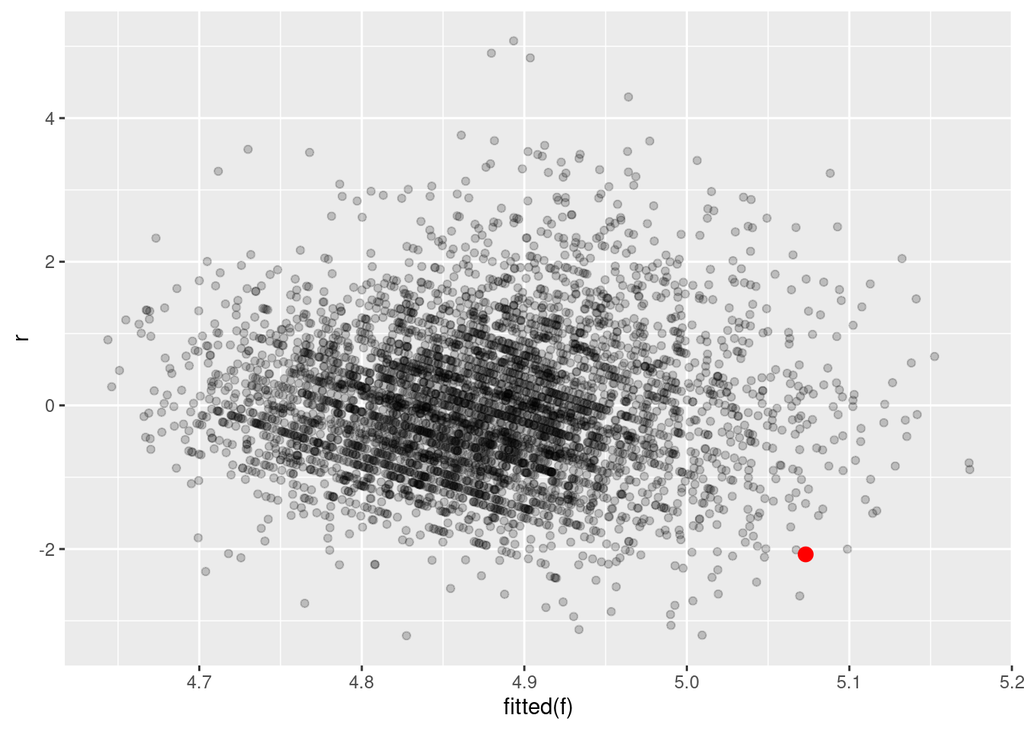

```r
r <- resid(f, type='studentized')
ggplot(mapping=aes(fitted(f), r)) +
  geom_point(alpha=.2) +
  geom_point(aes(x=fitted(f)[1], y=r[1], color=I('red'), size=I(3)))
```

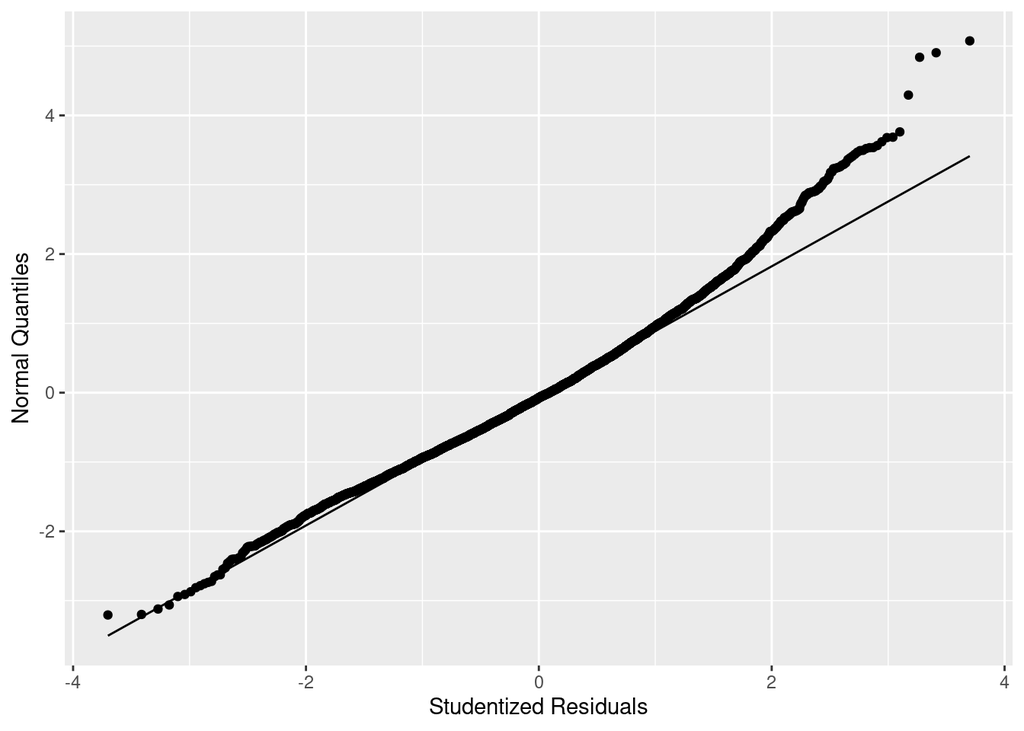

```r
ggplot(mapping=aes(sample=r)) + geom_qq() + stat_qq_line() +
  xlab('Studentized Residuals') + ylab('Normal Quantiles')
```

## 3.3 Influence Statistics

```r
w <- which.influence(f)
w
```

```
$age
[1] "1"

$`sex * age`
[1] "1"
```

```r
show.influence(w, d)
```

```
  Count  age
1     2 *103
```

The correct point was found, and it affected two parameter estimates (main age parameter and age $\times$ sex interaction; `Count`=2) by more than 0.2 standardized units (the default cutoff for `which.influence`).

# 4 Fit and Validate Model Without Outlier

Go back to the original imported data.

```r
d <- upData(fram,
            labels = .q(sbp = 'Systolic Blood Pressure',
                        bmi = 'Body Mass Index',
                        scl = 'Serum Cholesterol'),
            units  = .q(sbp = mmHg))
```

```
Input object size:   208704 bytes;   10 variables    4699 observations
New object size:    210544 bytes;   10 variables    4699 observations
```

## 4.1 Fit

```r
dd <- datadist(d); options(datadist='dd')
f <- ols(log(sbp) ~ sex * (log(bmi) + age + log(scl)),
         data=d, x=TRUE, y=TRUE)   # x, y needed for validations
f
```

**Linear Regression Model**

```
 ols(formula = log(sbp) ~ sex * (log(bmi) + age + log(scl)), data = d,
     x = TRUE, y = TRUE)
```

Frequencies of Missing Values Due to Each Variable

```
 log(sbp)      sex      bmi      age      scl
        0        0        9        0       33
```

|  | Model Likelihood Ratio Test | Discrimination Indexes |
| --- | --- | --- |
| Obs 4658 | LR χ<sup>2</sup> 1371.20 | *R*<sup>2</sup> 0.255 |
| σ 0.1393 | d.f. 7 | *R*<sup>2</sup><sub>adj</sub> 0.254 |
| d.f. 4650 | Pr(>χ<sup>2</sup>) 0.0000 | *g* 0.092 |

Residuals

```
      Min       1Q   Median       3Q      Max
 -0.44682 -0.09438 -0.01072  0.08137  0.70499
```

|  | β | S.E. | *t* | Pr(>\|*t*\|) |
| --- | --- | --- | --- | --- |
| Intercept | 3.7786 | 0.2404 | 15.72 | <0.0001 |
| sex | -0.2292 | 0.1432 | -1.60 | 0.1096 |
| bmi | 0.2309 | 0.0508 | 4.55 | <0.0001 |
| age | -0.0014 | 0.0008 | -1.65 | 0.0981 |
| scl | 0.0741 | 0.0378 | 1.96 | 0.0498 |
| sex × bmi | 0.0189 | 0.0293 | 0.65 | 0.5181 |
| sex × age | 0.0049 | 0.0005 | 9.39 | <0.0001 |
| sex × scl | -0.0090 | 0.0231 | -0.39 | 0.6960 |

## 4.2 Bootstrap Strong Internal Validation

The small difference between $R^2$ and $R^{2}_\text{adj}$ above previews the small amount of overfitting depicted below.

Use 300 bootstrap resamples for validation of statistical indexes, each of which is used to fit a model from scratch. Use 150 bootstraps for calibration just to save time.

```r
set.seed(17)    # so can replicate results
v <- validate(f, B=300)
html(v)
```

| Index | Original Sample | Training Sample | Test Sample | Optimism | Corrected Index | $n$ |
| --- | --- | --- | --- | --- | --- | --- |
| R-square | 0.255 | 0.2559 | 0.2537 | 0.0022 | 0.2528 | 300 |
| MSE | 0.0194 | 0.0194 | 0.0194 | 0 | 0.0194 | 300 |
| $g$ | 0.0916 | 0.0918 | 0.0914 | 4e-04 | 0.0912 | 300 |
| Intercept | 0 | 0 | 0.0164 | -0.0164 | 0.0164 | 300 |
| Slope | 1 | 1 | 0.9967 | 0.0033 | 0.9967 | 300 |

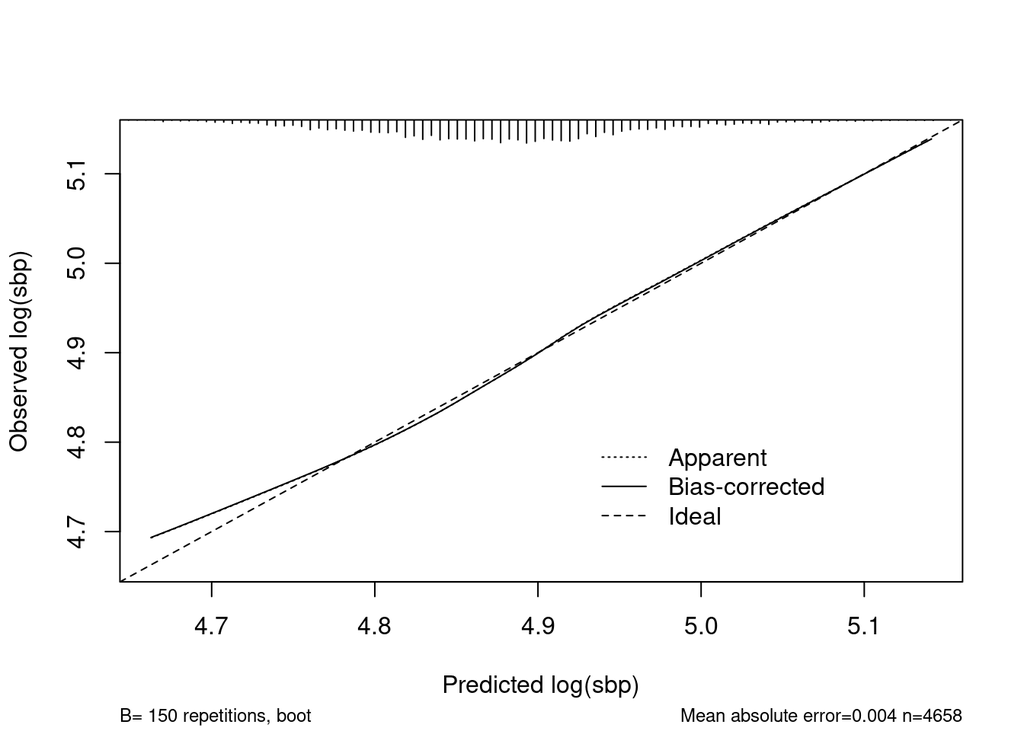

```r
cal <- calibrate(f, B=150)
plot(cal)
```

n=4658 Mean absolute error=0.004 Mean squared error=3e-05 0.9 Quantile of absolute error=0.006

The calibration curve looks excellent where predicted values are not rare.

- What is overfitting and why would it be a concern?
- What is optimism?
- Does an in-sample calibration plot provide useful information?
  - Plot of $Y$ vs. $\hat{Y}$ in the model development sample (whole sample)
- What is the in-sample mean |prediction error|?
- Does the in-sample mean |prediction error| over or under estimate the out-of-sample error?
- Compute the in-sample Spearman rank correlation
- What is the difference between discriminaton and calibration?

```r
# Compute mean |prediction error| on the original sbp scale
with(d, mean(abs(exp(fitted(f)) - sbp), na.rm=TRUE))
```

```
[1] 14.62888
```

```r
with(d, spearman(fitted(f), sbp))
```

```
      rho
0.5025522
```

```r
with(d, spearman(fitted(f), log(sbp)))
```

```
      rho
0.5025522
```

To cite R in publications use:

R Core Team (2022). *R: A Language and Environment for Statistical Computing*. R Foundation for Statistical Computing, Vienna, Austria. https://www.R-project.org/.

To cite the `Hmisc` package in publications use:

Harrell Jr F (2022). *Hmisc: Harrell Miscellaneous*. R package version 4.7-2, https://hbiostat.org/R/Hmisc/.

To cite the `rms` package in publications use:

Harrell Jr FE (2023). *rms: Regression Modeling Strategies*. https://hbiostat.org/R/rms/, https://github.com/harrelfe/rms.

To cite the `ggplot2` package in publications use:

Wickham H (2016). *ggplot2: Elegant Graphics for Data Analysis*. Springer-Verlag New York. ISBN 978-3-319-24277-4, https://ggplot2.tidyverse.org.

To cite the `survival` package in publications use:

Therneau T (2022). *A Package for Survival Analysis in R*. R package version 3.4-0, https://CRAN.R-project.org/package=survival.